# 概率论

# 概率

## 事件域、概率的定义

### 事件域的定义

设$\Omega$为一样本空间，事件域$\mathscr{F}$为$\Omega$的某些子集所组成的集合类，$\mathscr{F}$满足：

1. $\Omega \in \mathscr{F}$；
2. 若$A \in \mathscr{F}$，则$\bar{A} \in \mathscr{F}$；
3. 若$A_n \in \mathscr{F}$(n=1,2,…)，则$\mathop{\cup}\limits_{n=1}^\infty A_n \in \mathscr{F}$。

### 概率的定义

设$A$为$\mathscr{F}$上的任一事件，若定义在$\mathscr{F}$上的一个**实值函数**$P(A)$满足：

1. 非负性：$P(A)≥0$；
2. 正则性：$P(\Omega)=1$；
3. 可列可加性：若$A_1$, $A_2$, …, $A_n$, …互不相容，则$P(\mathop{\cup}\limits_{i=1}^\infty A_i)=\mathop{\sum}\limits_{i=1}^\infty P(A_i)$。

$(\Omega,\mathscr{F},P)$称为概率空间。

### 概率连续性的定义

1. $\mathscr{F}$中任意单调不减事件序列$F_1\subset F_2\subset F_3\subset...\subset F_n\subset ···$的极限事件为$\mathop{\cup}_\limits{n=1}^\infty F_n$，记作
   $$\lim_\limits{n\rightarrow\infty}F_n=\mathop{\cup}_\limits{n=1}^\infty
   F_n$$
   。
2. $\mathscr{F}$中任意单调不增事件序列$E_1\supset E_2\supset E_3\supset...\supset E_n\supset ···$的极限事件为$\mathop{\cap}_\limits{n=1}^\infty E_n$，记作
   $$\lim_\limits{n\rightarrow\infty}E_n=\mathop{\cap}_\limits{n=1}^\infty
   E_n$$
   。

对于$\mathscr{F}$上的一个概率$P$，

1. 若对于$\mathscr{F}$中任意单调不减事件序列$\{F_n\}$均有：
   $$\lim_\limits{n\rightarrow\infty}P(F_n)=P(\lim_\limits{n\rightarrow\infty}F_n)$$
   ，则称概率P是下连续的。
2. 若对于$\mathscr{F}$中任意单调不增事件序列$\{E_n\}$均有：
   $$\lim_\limits{n\rightarrow\infty}P(E_n)=P(\lim_\limits{n\rightarrow\infty}E_n)$$
   ，则称概率P是上连续的。

### 概率的连续性

若$P$是$\mathscr{F}$上的概率，则P既是下连续的，又是上连续的。

## 概率的确定

### 频率方法：重复试验估计概率

### 古典方法：

**两大抽样模型**——放回抽样模型与不放回抽样模型。

设有$N$件产品，其中$N-M$件合格品，$M$件不合格品，讨论在放回抽样与不放回抽下的情况下“取出的$n$件产品中有$m$件不合格品的概率（$m≤M, n-m≤N-M$）”。

1. 不放回抽样
   $$P=\frac{C_{N-M}^{n-m}C_M^m}{C_N^n}$$
2. 放回抽样（想象老虎机）
   $$P=\frac{C_n^m{(N-M)}^{n-m}M^m}{N^n}$$

例 全班同学生日问题（放回抽样模型）

全班$n$位同学至少有两人同一天过生日的概率$P=1-\frac{C_{365}^{n}n!}{365^n}$

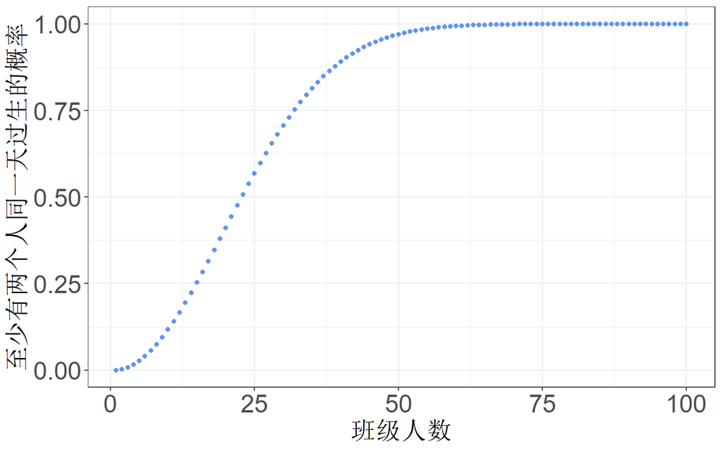

例 掷骰子获得最大点数的概率问题（放回抽样模型）

掷3个骰子，最大点数为$k$的概率计算方式：

1. 最大骰子数不大于$k$的概率为：$P_{≤k}=\frac{k^3}{6^3}$
2. 最大骰子数小于$k$的概率为：$P_{<k}=\frac{(k-1)^3}{6^3}$
3. 最大骰子数等于$k$的概率为：$P_{=k}=P_{≤k}-P_{<k}$

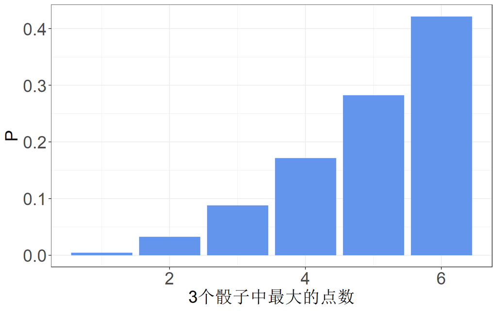

## 概率的性质

### 空集的概率为0

$$P(\emptyset)=0$$

### 互斥事件的概率互补

$$P(A)=1-P(\bar{A})$$

### 可列可加性

若有限个事件$A_1,A_2,...,A_n$互不相容，则有
$$P(\mathop{\cup}_{i=1}^nA_i)=\sum_{i=1}^nP(A_i)$$
。

### 单调性

若$A\supset B$，则
$$P(A-B)=P(A)-P(B)$$
。

**推论**：$P(A)\geq P(B)$。

### 任意事件之差

对于任意两个事件$A$、$B$，有
$$P(A-B)=P(A)-P(AB)$$
。

### 加法公式

对于任意两个事件$A$、$B$，有
$$P(A\cup
B)=P(A)+P(B)-P(AB)$$
。

**推论**：对任意$n$个事件$A_1,A_2,...,A_n$，有
$$P(\mathop{\cup}_{i=1}^nA_n)=\sum_{i=1}^nP(A_i)-\sum_{1≤i<j≤n}P(A_iA_j)+\sum_{1≤i<j<k≤n}P(A_iA_jA_k)+...+(-1)^{n-1}P(A_1A_2...A_n)$$
。（加法公式的好处在于每次只用考虑部分事件的概率，不必考虑剩余部分事件的概率）

**推论**：半可加性：对于任意两个事件，有
$$P(A\cup B)\leq P(A)+P(B)$$
；

对于任意$n$个事件，有
$$P(\mathop{\cup}_\limits{i=1}^nA_i)\leq
\sum_{i=1}^nP(A_i)$$
。

例 配对问题

$n$个人带了$n$件礼物，每人从中随机选取一件礼物，求事件$B$：“有人选中自己礼物”的概率。

### 下连续性、有限可加性$\Leftrightarrow$可列可加性

设$P$是$\mathscr{F}$上的函数满足：

1. $P(\Omega)=1$；
2. $P$非负；

则$P$具有可列可加性的充要条件是：

1. $P$具有有限可加性；
2. $P$具有下连续性。

# 条件概率与独立性

## 条件概率

### 条件概率的定义

设$A$与$B$是$\Omega$中的两个事件，若$P(B)>0$，则
$$P(A|B)=\frac{P(AB)}{P(B)}$$
为在$B$发生下$A$的条件概率。（A的概率空间发生了转换：$(\Omega,\mathscr{F},P)\Rightarrow(B,\mathscr{F}',P)$）

### 条件概率具有概率的基本定义的性质

1. $P(A|B)\geq0$；
2. $P(\Omega|B)=1$；
3. 若$A_1,A_2,...,A_3,...$互不相容，则
   $$P(\mathop{\cup}_\limits{n=1}^\infty
   A_n|B)=\sum_{n=1}^\infty P(A_n|B)$$
   。

### 乘法公式

若$P(B)>0$，则
$$P(AB)=P(B)P(A|B)$$
。

**推论**：若$P(A_1A_2...A_{n-1})>0$，则
$$P(A_1A_2...A_n)=P(A_1)P(A_2|A_1)P(A_3|A_1A_2)...P(A_n|A_1A_2...A_{n-1})$$
。

### 全概率公式

若$B_1,B_2,...B_n$为样本空间$\Omega$的一个分割，且$P(B_i)>0,\ (i=1,2,...,n)$，则对于任一事件$A$有
$$P(A)=\sum_{i=1}^nP(B_i)P(A|B_i)$$
。

**推论**：若$B_1,B_2,...B_n$互不相容，且$A\subset\mathop{\cup}_\limits{i=1}^nB_i$，则全概率公式依然成立。

**推论**：若$B_1,B_2,...B_n,...$互不相容，且$A\subset\mathop{\cup}_\limits{i=1}^\infty B_i$，则全概率公式依然成立。

### 贝叶斯公式

若$B_1,B_2,...B_n$为样本空间$\Omega$的一个分割，且$P(A)>0,P(B_i)>0,\ (i=1,2,...,n)$，则
$$P(B_i|A)=\frac{P(A|B_i)P(B_i)}{\sum_{j=1}^nP(B_j)P(A|B_j)}$$
。其中$P(B_i)$为先验概率，$P(B_i|A)$为后验概率。

## 独立性

### 独立性定义

若
$$P(AB)=P(A)P(B)$$
，即
$$P(A|B)=P(A)$$
，则事件$A$与$B$相互独立，即将$A$的样本空间$\Omega$更新为$B$不影响A的概率。

### 独立性基本性质

若$A$与$B$相互独立，则$A$与$\bar{B}$、$\bar{A}$与$\bar{B}$、$\bar{A}$与$B$相互独立。

### 多个事件的独立性定义

若
$$\begin{cases}
P(AB)=P(A)P(B)\\
P(AC)=P(A)P(C)\\
P(BC)=P(B)P(C)\\
P(ABC)=P(A)P(B)P(C)
\end{cases}$$
，则事件$A$、$B$、$C$相互独立。

**推论**：对任意的$1\leq i<j<k<...\leq n$，若
$$\begin{cases}
p(A_iA_j)=P(A_i)P(A_j)\\
P(A_iA_jA_k)=P(A_i)P(A_j)P(A_k)\\
......\\
P(A_1A_2...A_n)=P(A_1)P(A_2)...P(A_n)\\
\end{cases}$$
，则事件$A_1,A_2,..,A_n$相互独立。

### 独立性试验

如果试验$E_1$的任一结果（事件）都与试验$E_2$的任一结果（事件）相互独立，则这两个试验是相互试验。若有$n$个这样的试验则称其为$n$重独立重复试验。若其中每个试验的结果（事件）只有两个，则称其为$n$重Bernoulli试验。

# 随机变量

## 随机变量

定义在样本空间$\Omega$上的实值函数$X=X(w)$是随机变量。

## 分布函数

### 分布函数的定义

设随机变量$X$、任意实数$x$，称
$$F(x)=P(X\leq x)$$
为随机变量$X$的分布函数。

任意随机变量都有一个分布函数。

### 分布函数的性质

1. 单调性。$\forall x_1<x_2\in R$，有$F(x_1)\leq F(x_2)$。
2. 有界性。$\forall x\in R$，有$0\leq F(x)\leq1$，且
   $$F(-\infty)=\lim_\limits{x\rightarrow-\infty}F(x)=0$$
   ，
   $$F(+\infty)=\lim_\limits{x\rightarrow+\infty}F(x)=1$$
   。
3. 右连续性。$\forall x_0\in R$，有
   $$\lim_\limits{x\rightarrow
   x_0^+}F(x)=F(x_0)$$

（连续随机变量的分布函数是$R$上的连续函数。）

## 离散随机变量

### 分布列的定义

对于离散随机变量$X$的所有取值$x_1,x_2,...,x_n,...$，$P(X=x_i)=p(x_i),\ (i=1,2,...,n,...)$为$X$的概率分布列。

### 分布列的性质

1. 非负性：$p(x_i)\geq0,\ (i=1,2,...,n,...)$。
2. 正则性：$\sum_{i=1}^\infty p(x_i)=1$。

## 连续随机变量

### 概率密度函数的定义

如果存在一个在$R$上可积的函数$p(x)$，使得$\forall x\in R$，有
$$F(x)=\int_{-\infty}^xp(t)dt$$
，则称$p(x)$为$X$的概率密度函数。

### 概率密度函数的性质

1. 非负性：$p(x)\geq0$；
2. 正则性：$\int_{-\infty}^{\infty}p(x)dx=1$

连续随机变量的分布函数是$R$上的连续函数。

## 期望

### 离散随机变量期望的定义

设离散随机变量$X$的分布列$p(x_i),\ (i=1,2,...,n,...)$，如果
$$\sum_{i=1}^\infty
|x_i|p(x_i)$$
存在，则$X$的数学期望为
$$E(X)=\sum_{i=1}^\infty x_ip(x_i)$$
。

### 连续随机变量期望的定义

设连续随机变量$X$的概率密度函数为$p(x)$，如果
$$\int_{-\infty}^\infty|x|p(x)dx$$
存在，则$X$的数学期望为
$$E(X)=\int_{-\infty}^{\infty}xp(x)dx$$
。

### 随机变量函数的数学期望定理

$X$的某一函数$g(X)$的数学期望为
$$E[g(X)]=\begin{cases}
\sum_{i=1}^\infty g(x_i)p(x_i),\ 离散场合\\
\int_{-\infty}^\infty g(x)p(x)dx,\ 连续场合
\end{cases}$$

## 方差

### 方差的定义

若$E(X^2)$存在，则$E[X-E(X)]^2$为随机变量$X$的方差，
$$Var(X)=\begin{cases}
\sum_{i=1}^\infty [x_i-E(X)]^2p(x_i),\ 离散场合\\
\int_{-\infty}^\infty [x-E(X)]^2p(x)dx,\ 连续场合
\end{cases}$$

### 方差的性质

1. $Var(X)=E(X^2)-[E(X)]^2$；
2. $Var(c)=0$，$c$为常数；
3. $Var(aX+b)=a^2Var(X)$，$a,b$为常数。

## Chebyshev不等式

若$X$的方差存在，则$\forall\ \varepsilon>0$，有
$$P\big{(}|X-E(X)|\geq\varepsilon\big{)}\leq\frac{Var(X)}{\varepsilon^2}$$
或
$$P\big{(}|X-E(X)|<\varepsilon\big{)}>1-\frac{Var(X)}{\varepsilon^2}$$
。

# 常用分布

## 离散分布

$n$重Bernoulli试验是最基础的离散随机现象

### 二项分布

$n$重Bernoulli试验中，事件发生总次数的随机变量$X$服从二项分布，$X\sim b(n,p)$，
$$P(X=k)=C_n^kp^k(1-p)^{n-k},\
(k=0,1,...,n)$$
。
$$E(X)=np$$
$$Var(X)=np(1-p)$$

### Poisson分布

$n$重Bernoulli试验（当$n\rightarrow\infty$时）中（也叫Bernoulli试验序列），事件发生总次数的随机变量$X$服从Poisson分布，$X\sim P(\lambda)$，其中$\lambda=\lim_\limits{n\rightarrow\infty}np_n$，
$$P(X=k)=\frac{\lambda^k}{k!}e^{-\lambda},\
(k=0,1,...,n,...)$$
。
$$E(X)=\lambda$$
$$Var(X)=\lambda$$

（Poisson分布可用于拟合在连续时间或连续空间上发生离散事件次数的分布，如某段时间内进入超市的顾客的总数。将该时间段分为无穷多个小时间段，每个小时间段都是相同的两点分布）

#### Poisson定理

设在$n$重Bernoulli试验中，事件发生的概率为$p_n$。若

1. $\lim_\limits{n\rightarrow\infty}np_n$存在，并令极限为$\lambda$；

则，
$$\lim_\limits{n\rightarrow\infty}C_n^kp^k(1-p)^{n-k}=\frac{\lambda^k}{k~}e^{-\lambda}$$
。

### 几何分布

在Bernoulli试验序列中，目标事件首次出现的试验次数$X$的分布，$X\sim Ge(p)$，
$$P(X=k)=(1-p)^{k-1}p,\ (k=1,2,...)$$
。
$$E(X)=\frac{1}{p}$$
$$Var(X)=\frac{1-p}{p^2}$$

#### 几何分布无记忆性

设$X\sim Ge(p)$，$\forall\ m,n\in N_+$，有
$$P(X>m+n|X>m)=P(X>n)$$
。

事件$\{X>m\}$表示试验$m$次目标事件仍未发生。

### 负二项分布

在Bernoulli试验序列中，目标事件第$r$次出现的试验次数$X$的分布，$X\sim Nb(r,p)$，
$$P(X=k)=C_{k-1}^{r-1}p^{r}(1-p)^{k-r},\
(k=r,r+1,...)$$
。
$$E(X)=\frac{r}{p}$$
$$Var(X)=\frac{r(1-p)}{p^2}$$

#### 负二项分布与几何分布的关系

若$X_i\sim Ge(p),\ (i=1,2,...,r)$，且诸$X_i$相互独立，则
$$\sum_{i=1}^rX_i\sim Nb(r,p)$$

### 超几何分布

超几何分布是二元抽样分布。

设总体有$N$个，其中含有目标$M$个，现从总体中无放回抽样$n$个，抽到目标样本的个数为$X$，$X\sim h(n,N,M)$,
$$P(X=k)=\frac{C_M^kC_{N-M}^{n-k}}{C_N^n},\
(k=0,1,...,n)$$
。
$$E(X)=n\frac{M}{N}$$
$$Var(X)=\frac{nM(N-M)(N-n)}{N^2(N-1)}$$

## 连续分布

### 正态分布

$X\sim N(\mu,\sigma^2)$，
$$p(x)=\frac{1}{\sqrt{2\pi}\sigma}e^{-\frac{(x-\mu)^2}{2\sigma^2}},\
x\in R$$
。
$$E(x)=\mu$$
$$Var(X)=\sigma^2$$

$$P(|X-\mu|<\sigma)≈70\%$$
$$P(|X-\mu|<2\sigma)≈95\%$$
$$P(|X-\mu|<3\sigma)≈99\%$$

### 均匀分布

$X\sim U(a,b)$，
$$p(x)=\begin{cases}
\frac{1}{b-a},\ x\in (a,b)\\
0,\ 其他
\end{cases}$$
$$E(X)=\frac{a+b}{2}$$
$$Var(X)=\frac{(b-a)^2}{12}$$

### 指数分布

在时间段$[0,t]$中，事件发生的总次数$X$服从$P(\lambda t)$，则事件首次发生所经过的时间$T$服从$Exp(\lambda)$。（书上对此的证明不足，不过它大致说明了指数分布提出的原因）
$$p(x)=\begin{cases}
\lambda e^{-\lambda x},\ x\geq0\\
0\ \ \ \ \ \ \ \ ,\ x<0
\end{cases}$$
$$E(X)=\frac{1}{\lambda}$$
$$Var(X)=\frac{1}{\lambda^2}$$

### 伽马分布

在时间段$[0,t]$中，事件发生的总次数$X$服从$P(\lambda t)$，则事件第$\alpha$次发生所经过的时间$T$服从$Ga(\alpha,\lambda)$。

伽玛函数：$\Gamma(\alpha)=\int_0^\infty x^{\alpha-1}e^{-x}dx,\ (\alpha>0)$。

1. $\Gamma(1)=1$，$\Gamma(\frac{1}{2})=\sqrt{\pi}$；
2. $\Gamma(\alpha+1)=\alpha\Gamma(\alpha)$，$\Gamma(n+1)=n!,\ (n为自然数)$。

伽马分布密度函数：
$$p(x)=\begin{cases}
\frac{\lambda^a}{\Gamma(\alpha)}x^{\alpha-1}e^{-\lambda x},\ x\geq0\\
0\ \ \ \ \ \ \ \ \ \ \ \ \ \ \ \ \ \ \ \ \ ,x<0
\end{cases}$$
。

$$E(X)=\frac{\alpha}{\lambda}$$
$$Var(X)=\frac{\alpha}{\lambda^2}$$

伽玛分布特例：

1. $Ga(1,\lambda)=Exp(\lambda)$；
2. $Ga(\frac{n}{2},\frac{1}{2})=\chi^2(n)$。

### 贝塔分布

贝塔函数：$B(a,b)=\int_0^1x^{a-1}(1-x)^{b-1}dx,\ (a,b>0)$。

1. $B(a,b)=B(b,a)$；
2. $B(a,b)=\frac{\Gamma(a)\Gamma(b)}{\Gamma(a+b)}$。

贝塔分布密度函数：
$$p(x)=\begin{cases}
\frac{\Gamma(a+b)}{\Gamma(a)\Gamma(b)}x^{a-1}(1-x)^{b-1},\ x\in (0,1)\\
0\ \ \ \ \ \ \ \ \ \ \ \ \ \ \ \ \ \ \ \ \ \ \ \ \ \ \ \ \ \ \ \ \ \ \ \
\ \ \ \ ,其他
\end{cases}$$
。

$$E(X)=\frac{a}{a+b}$$
$$Var(X)=\frac{ab}{(a+b)^2(a+b+1)}$$

# 随机变量函数的分布

## $Y=g(X)$为离散随机变量

## $y=g(x)$为严格单调函数

**定理**：设$X$为连续随机变量，$Y=g(X)$。若

1. $y=g(x)$严格单调；
2. $g(x)$的反函数$h(y)$具有连续导函数；

则$Y$的密度函数为
$$p_Y(y)=\begin{cases}
p_X[h(y)]|h'(y)|,\ y\in(a,b)\\
0\ \ \ \ \ \ \ \ \ \ \ \ \ \ \ \ \ \ \ ,\ 其他
\end{cases}$$
， 其中$a=min\{g(-\infty),g(+\infty)\}$，$b=max\{g(-\infty),g(+\infty)\}$。

**定理**：设$X\sim N(\mu,\sigma^2)$，若

1. $Y=aX+b,\ (a≠0)$；

则
$$Y\sim
N(a\mu+b,(a\sigma)^2)$$
。

**定义 对数正态分布**：若$X\sim N(\mu,\sigma^2)$，则$Y=e^X$的概率密度函数为
$$p_Y(y)=\begin{cases}
\frac{1}{\sqrt{2\pi}y\sigma}exp\{-\frac{(\ln
y-\mu)^2}{2\sigma^2}\},y>0\\
0\ \ \ \ \ \ \ \ \ \ \ \ \ \ \ \ \ \ \ \ \ \ \ \ \ \ \ \ \ \ \ \ \ \ \
,y\leq0
\end{cases}$$
， $Y$服从对数正态分布，记$Y\sim LN(\mu,\sigma^2)$，其中
$$E(Y)=e^{\mu+\frac{\sigma^2}{2}}\ \ \ \ \
Var(Y)=(e^{\sigma^2}-1)e^{2\mu+\sigma^2}$$
。

**定理**：设$X\sim Ga(\alpha,\lambda)$，若

1. $Y=kX,\ k>0$

则
$$Y\sim
Ga(\alpha,\frac{\lambda}{k})$$
。

任一伽玛分布都可以转化为$\chi^2$分布。

**定理**：设$X$及其分布函数$F_X(x)$，若

1. $F_X(x)$连续；
2. $F_X(x)$严格单调递增；

则$Y=F_X(X)\sim U(0,1)$。

通过均匀分布可以转化为其他连续分布，在计算机模拟随机数中有应用。

## $g(x)$为其他形式

从$F_Y(y)=P(g(X)\leq y)$出发计算。

# 分布特征数

## k阶矩

$X$为随机变量，$k$为正整数，
$$\mu_k=E(X^k)$$
为$X$的$k$阶原点矩；
$$v_k=E(X-E(X))^k$$
为$X$的$k$阶中心矩。

## 变异系数

$X$的二阶矩存在，
$$C_v(X)=\frac{\sqrt{Var(X)}}{E(X)}$$
为$X$的变异系数。

## 分位数

$X$为连续随机变量，满足
$$F(x_p)=\int_{-\infty}^{x_p}p(x)dx=p,\
(0<p<1)$$
的$x_p$称为$X$分布的下侧$p$分位数；上侧$p$分位数$x_p'=x_{1-p}$；中位数为$x_{0.5}$。

## 偏度系数

$X$的前3阶矩存在，则
$$\beta_S=\frac{v_3}{v_2^{3/2}}$$
为$X$的偏度系数。$\beta_S>0，右偏$；$\beta_S<0，左偏$。

## 峰度系数

$X$的前4阶矩存在，则
$$\beta_k=\frac{v_4}{v_2^2}-3$$
为$X$的峰度系数。$\beta_k>0$，比正态分布更尖峭。

# 多维随机变量

## 多维随机变量

### 多维随机变量的定义

如果$X_1$、$X_2$、$\cdots$、$X_n$是同一个样本空间$\Omega$上的$n$个随机变量，那么称
$$\boldsymbol{X}=(X_1,X_2,...,X_n)$$
为$n$维随机变量（随机向量）。

### 联合分布函数的定义

$n$个事件$\{X_1\leq x_1\}$、$\{X_2\leq x_2\}$、$\cdots$、$\{X_n\leq x_n\}$同时发生的概率
$$F(x_1,x_2,\cdots,x_n)=P(X_1\leq x_1,X_2\leq
x_2,\cdots,X_n\leq x_n)$$
称为$\boldsymbol{X}$的联合分布函数。

### 二维联合分布函数的性质

1. 单调性。$F(x,y)$分别对$x$和$y$都是单调不减函数。
2. 有界性。$\forall\ (x,y)\in R^2$，有$0\leq F(x,y)\leq1$，且
   $$F(-\infty,y)=F(x,-\infty)=0$$
   $$F(\infty,\infty)=1$$
   。
3. 右连续性。$F(x,y)$分别对$x$和$y$都是右连续的。
4. 非负性。
   $$P(a<X\leq b,c<Y\leq
   d)=F(b,d)+F(a,c)-F(b,c)-F(a,d)\geq0$$
   。

### 联合分布列

$P(X=x_i,Y=y_j)$为二维离散随机变量$(X,Y)$的联合分布列，它满足：

1. 非负性：$P(X=x_i,Y=y_j)\geq0$。
2. 正则性：$\sum_{i=1}^{\infty}\sum_{j=1}^{\infty}P(X=x_i,Y=y_j)=1$。

### 联合密度函数

如果存在二元非负函数$p(x,y)$使得
$$F(x,y)=\int_{-\infty}^x\int_{-\infty}^yp(u,v)dudv$$
，则称$p(x,y)$为连续随机变量$(X,Y)$的联合密度函数，它满足：

1. 非负性：$p(x,y)\geq0$。
2. 正则性：$\int_{-\infty}^{\infty}\int_{-\infty}^{\infty}p(x,y)dxdy=1$。

## 常用多维分布

### 多项分布

$n$重独立重复试验中，样本空间的$n$个分割事件$A_1$、$A_2$、$\cdots$、$A_r$分别发生的次数$n_1$、$n_2$、$\cdots$、$n_r$的随机向量$\boldsymbol{X}_{r-1}$服从$r$项分布，$\boldsymbol{X}_{r-1}\sim M(n,p_1,p_2,\cdots,p_r)$，
$$P(X_1=n_1,X_2=n_2,\cdots,X_r=n_r)=\frac{n!}{n_1!n_2!\cdots
n_r!}p_1^{n_1}p_2^{n_2}\cdots p_r^{n_r}$$
，其中$n=n_1+n_2+\cdots+n_r$。

### 多维超几何分布

多维超几何分布是多元抽样分布。

设总体有$N$个，其中包含$N_1$、$N_2$、$\cdots$、$N_r$个不同种类组份组成对总体$N$的一个分割，现从总体中无放回抽样$n$个样本，其中包含的各组分的个数$n_1$、$n_2$、$\cdots$、$n_r$的随机向量$\boldsymbol{X}_{r-1}$服从多维超几何分布，
$$P(X_1=n_1,X_2=n_2,\cdots,X_r=n_r)=\frac{C_{N_1}^{n_1}C_{N_2}^{n_2}\cdots
C_{N_r}^{n_r}}{C_N^n}$$
。

### 二元正态分布

二元正态分布的联合密度函数为：
$$p(x,y)=\frac{1}{2\pi\sigma_1\sigma_2\sqrt{1-\rho^2}}e^{-\frac{1}{2(1-\rho^2)}\big{[}\frac{(x-u_1)^2}{\sigma_1^2}-2\rho\frac{(x-u_1)(y-u_2)}{\sigma_1\sigma_2}+\frac{(y-u_2)^2}{\sigma_2^2}\big{]}}$$
。

### 多元正态分布

$n$元随机变量$\boldsymbol{X}$的联合正态密度函数为：
$$p(\boldsymbol{x})=\frac{1}{(2\pi)^{\frac{n}{2}}|Cov(\boldsymbol{X})|^{\frac{1}{2}}}e^{-\frac{1}{2}[\boldsymbol{x}-E(\boldsymbol{x})]^{T}[Cov(\boldsymbol{X})]^{-1}[\boldsymbol{x}-E(\boldsymbol{X})]}$$
。

## 边际分布

### 边际分布函数

在联合分布函数中，令其他变量为必然事件，则可得目标变量的边际分布函数。例如在$F(x,y)$中令$y\rightarrow+\infty$，则$F(x,+\infty)=F_X(x)$。

### 边际分布列

$$P(X=x_i)=\sum_{j=1}^{+\infty}P(X=x_i,Y=y_j)$$
。

### 边际密度函数

$$p_X(x)=\int_{-\infty}^{+\infty}p(x,y)dy$$
。

例 二维指数分布

$$F(x,y)=\begin{cases}
1-e^{-x}-e^{-y}+e^{-x-y-\lambda xy},\ \ x\geq0,y\geq0\\
0,\ \ \ 其他
\end{cases}$$

$$F_X(x)=\begin{cases}
1-e^{-x},\ \ x\geq0\\
0,\ \ x<0
\end{cases}$$

例 三项分布

$(X,Y)\sim M(n,p_1,p_2,p_3)$，则$X\sim b(n,p_1)$，$Y\sim b(n,p_2)$。

例 二维正态分布

$(X,Y)\sim N(\mu_1,\mu_2,\sigma_1^2,\sigma_2^2,\rho)$，则$X\sim N(\mu_1,\sigma^2_1)$，$Y\sim N(\mu_2,\sigma_2^2)$。

## 随机变量的独立性的定义

若$\boldsymbol{X}_n$的联合分布函数$F(\boldsymbol{x})$满足
$$F(\boldsymbol{x})=\prod_{i=1}^{n}F_i(x_i)$$
，其中$X_i\sim F_i(x_i)$，则称$X_1$、$X_2$、$\cdots$、$X_n$相互独立。

在离散随机变量场合：若
$$P(X_1=x_1,X_2=x_2,\cdots,X_n=x_n)=\prod_{i=1}^{n}P(X_i=x_i)$$
，则称$X_1$、$X_2$、$\cdots$、$X_n$相互独立。

在离散随机变量场合：若
$$p(x_1,x_2,\cdots,x_n)=\prod_{i=1}^{n}p_i(x_i)$$
，则称$X_1$、$X_2$、$\cdots$、$X_n$相互独立。

# 多维随机变量函数的分布

多维随机变量函数是指$Y=g(X_1,X_2,\cdots,X_n)$。

## 离散场合

### Poisson分布的可加性

若随机变量$X$与$Y$满足：

1. $X\sim P(\lambda_1)$，$Y\sim P(\lambda_2)$；
2. $X$与$Y$相互独立；

则$X+Y\sim P(\lambda_1+\lambda_2)$

### 二项分布的可加性

若随机变量$X$与$Y$满足：

1. $X\sim b(n,p)$，$Y\sim b(m,p)$；
2. $X$与$Y$相互独立；

则$X+Y\sim b(m+n,p)$。

### Gamma分布的可加性

若随机变量$X$与$Y$满足：

1. $X\sim Ga(\alpha_1,\lambda)$，$Y\sim Ga(\alpha_2,\lambda)$；
2. $X$与$Y$相互独立；

则$X+Y\sim Ga(\alpha_1+\alpha_2,\lambda)$。

## 最大、最小值分布

### 最大值分布

若随机变量$X_1$、$X_2$、$\cdots$、$X_n$满足：

1. $X_i\sim F_i(x)$；
2. $X_1$、$X_2$、$\cdots$、$X_n$相互独立；

则
$$F_Y(y)=\prod_{i=1}^{n}F_i(y)$$
，其中$Y=\max\{X_1,X_2,\cdots,X_n\}$。

### 最小值分布

若随机变量$X_1$、$X_2$、$\cdots$、$X_n$满足：

1. $X_i\sim F_i(x)$；
2. $X_1$、$X_2$、$\cdots$、$X_n$相互独立；

则
$$F_Y(y)=1-\prod_{i=1}^{n}\big{[}1-F_i(y)\big{]}$$
，其中$Y=\min\{X_1,X_2,\cdots,X_n\}$。

**推论**：若$X_i\sim Exp(\lambda)$，$X_1$、$X_2$、$\cdots$、$X_n$相互独立，则$Y\sim Exp(n\lambda)$，其中$Y=\min\{X_1,X_2,\cdots,X_n\}$。

## 连续场合

### 卷积公式

若连续随机变量$X$与$Y$满足：

1. 相互独立；
2. 密度函数分别为$p_X(x)$和$p_Y(y)$；

则$Z=X+Y$的密度函数为：
$$p_Z(z)=\int_{-\infty}^{+\infty}p_X(z-y)p_Y(y)dy=\int_{-\infty}^{+\infty}p_X(x)p_Y(z-x)dx$$
。

### 正态分布的可加性

若随机变量$X$与$Y$满足：

1. $X\sim N(\mu_1,\sigma_1^2)$，$Y\sim N(\mu_2,\sigma_2^2)$；
2. $X$与$Y$相互独立；

则$X+Y\sim N(\mu_1+\mu_2,\sigma_1^2+\sigma_2^2)$。

### 变量变换法

若$(U,V)$满足：

1. $\begin{cases}U=u(X,Y)\\V=v(X,Y)\end{cases}$；
2. 函数$u$和$v$存在连续一阶偏导数，且
   $$J=\begin{vmatrix}\frac{\partial u}{\partial
   x}&\frac{\partial u}{\partial y}\\\frac{\partial v}{\partial
   x}&\frac{\partial v}{\partial
   y}\end{vmatrix}\neq0$$
   。

则
$$p_{UV}(u,v)=p_{XY}(x(u,v),y(u,v))|J|^{-1}$$
。

# 多维随机变量的特征数

## 期望与方差

### 随机变量函数的数学期望

若$Z=g(X,Y)$满足：

1. $Z$的数学期望存在；

则
$$E(Z)=\begin{cases}
\sum_{i}\sum_jg(x_i,y_i)P(X=x_i,Y_i=y_i),\ \ 离散\\
\int_{-\infty}^{+\infty}\big{(}\int_{-\infty}^{+\infty}g(x,y)p(x,y)dx\big{)}dy,\
\ 连续
\end{cases}$$
。

### 期望性质1

若$X$、$Y$满足：

1. $E(X)$、$E(Y)$都存在；

则$E(X\pm Y)$存在，且
$$E(X\pm Y)=E(X)\pm E(Y)$$
。

### 期望性质2

若$X$、$Y$满足：

1. $E(X)$、$E(Y)$都存在；
2. $X$与$Y$相互独立；

则$E(XY)$存在，且
$$E(XY)=E(X)E(Y)$$
。

### 方差性质1

若$X$、$Y$满足：

1. $Var(X)$、$Var(Y)$都存在；
2. $X$与$Y$相互独立（或不相关）；

则$Var(X\pm Y)$存在，且
$$Var(X\pm Y)=Var(X)+Var(Y)$$
。

### 方差性质2：

若$X$、$Y$满足：

1. $Var(X)$、$Var(Y)$都存在；

则$Var(X\pm Y)$存在，且
$$Var(X\pm Y)=Var(X)+Var(Y)\pm
2Cov(X,Y)$$
。

**推论**：若$X_1$，$X_2$，$\cdots$，$X_n$满足：

1. $Var(X_i)\ \ i=(1,2,\cdots,n)$都存在；

则$Var\big{(}\sum_{i=1}^{n}X_i\big{)}$存在，且
$$Var\big{(}\sum_{i=1}^{n}X_i\big{)}=\sum_{i=1}^nVar(X_i)+2\sum_{1\leq
i<j\leq n}Cov(X_i,X_j)$$
。

## 协方差

### 协方差的定义

若$X$，$Y$满足：

1. $E\big{[}\big{(}X-E(X)\big{)}\big{(}Y-E(Y)\big{)}\big{]}$存在；

则称此期望为协方差，记作$Cov(X,Y)$。

### 协方差定理1

若$X$，$Y$满足：

1. $E(X)$、$E(Y)$、$E(XY)$都存在；

则$Cov(X,Y)$存在，且
$$Cov(X,Y)=E(XY)-E(X)E(Y)$$
。

### 协方差定理2

若$X$，$Y$满足：

1. $E(X)$、$E(Y)$、$E(XY)$都存在；
2. $X$与$Y$相互独立；

则$Cov(X,Y)=0$。

### 协方差性质

$$Cov(X,Y)=Cov(Y,X)$$
$$Cov(X,a)=0$$
$$Cov(aX,bY)=abCov(X,Y)$$
$$Cov(X\pm Y,Z)=Cov(X,Z)\pm Cov(Y,Z)$$

## 相关系数

### 相关系数的定义

若$X$、$Y$满足：

1. $Cov(X,Y)$、$Var(X)>0$、$Var(Y)>0$都存在；

则$X$与$Y$的（线性）相关系数为
$$Corr(X,Y)=\frac{Cov(X,Y)}{\sqrt{Var(X)}\sqrt{Var(Y)}}$$
，它是标准化随机变量之间的协方差。

### Schwarz不等式

若$X$、$Y$满足：

1. $Cov(X,Y)$、$Var(X)$、$Var(Y)$都存在；

则
$$\big{[}Cov(X,Y)\big{]}^2\leq
Var(X)Var(Y)$$
。

### 相关系数性质1

$$-1\leq Corr(X,Y)\leq1$$

### 相关系数性质2

$Corr(X,Y)=\pm1$ 等价于$\Leftrightarrow$$X$与$Y$之间几乎处处有线性关系。

# 条件分布

## 离散随机变量

### 离散随机变量的条件分布列

$$P(X=x_i|Y=y_i)=\frac{P(X=x_i,Y=y_i)}{P(Y=y_i)}$$
。

### 离散随机变量的条件分布函数

$$F(x|y_i)=\sum_{x_i\leq
x}P(X=x_i|Y=y_i)$$
。

## 连续随机变量

### 连续随机变量的条件密度函数

$$p(x|y)=\frac{p(x,y)}{p_Y(y)}$$
。

### 连续随机变量的条件分布函数

$$F(x|y)=\int_{-\infty}^x\frac{p(u,y)}{p_Y(y)}du$$
。

例1

若$(X,Y) \sim N(\mu_1,\,u_2,\sigma_1^2,\sigma_2^2,\rho)$，则$Y|X=x \sim N(\mu_2+\rho\frac{\sigma_2}{\sigma_1}(x-\mu_1),\sigma_2^2(1-\rho^2))$。

例2

若$X \sim N(\mu,\sigma_1^2)$，$Y \sim N(x,\sigma_2^2)$，则$Y\sim N(\mu,\sigma_1^2+\sigma_2^2)$，$Cov(X,Y)=\sigma_1^2$。

## 条件期望

$$E(X|Y=y)=\begin{cases}\sum_ix_iP(X=x_i|Y=y)\ \
\ 离散场合\\\int_{-\infty}^{+\infty}xp(x|y)dx\ \ \
连续场合\end{cases}$$

## 重期望

$$E(X)=E[E(X|Y)]$$

例3 随机个独立同分布随机变量和的数学期望

设独立同分布随机变量序列$X_1$、$X_2$、$\cdots$、$X_N$，$N$为正整数随机变量，$N$与$X_i\ (i=1,2,\cdots,N)$相互独立，则
$$E(\sum_{i=1}^NX_i)=E(X_1)E(N)$$
。

# 大数定律

## Markov大数定律

若$\{X_n\}$满足：

1. $Var(X_n)$存在；
2. $\lim_\limits{n\rightarrow\infty}Var(\frac{1}{n}\sum_{i=1}^nX_n)=0$；

则
$$\lim_\limits{n\rightarrow\infty}P\bigg{(}\Big{|}\frac{1}{n}\sum_{i=1}^nX_n-\frac{1}{n}\sum_{i=1}^{n}E(X_n)\Big{|}<\varepsilon\bigg{)}=1$$
。

**推论1**：Chebyshev大数定律：

若$\{X_n\}$满足：

1. $Var(X_n)$存在；
2. 两两不相关，且$\forall\ n\in N_+$，$Var(X_n)\leq c$，$c$为常数；

则$\{X_n\}$满足大数定律。

**推论2**：Bernoulli大数定律：

若$\{X_n\}$满足：

1. 表示$n$重Bernoulli实验；

则$\{X_n\}$满足大数定律。

## Khinchin大数定律

若$\{X_n\}$满足：

1. $E(X_n)$存在；
2. 独立同分布；

则$\{X_n\}$满足大数定律。

# 中心极限定理

## 林德伯格-莱维中心极限定理

若$\{X_n\}$满足：

1. $Var(X)>0$存在；
2. 独立同分布；

则
$$\lim_\limits{n\rightarrow\infty}\frac{\sum_{i=1}^nX_i-nE(X)}{\sqrt{nVar(X)}}\sim
N(0,1)$$

## 林德伯格中心极限定理

若$\{X_n\}$满足：

1. 林德伯格条件；
2. 相互独立；

则
$$\lim_\limits{n\rightarrow\infty}\frac{\sum_{i=1}^nX_i-\sum_{i=1}^nE(X_i)}{\sqrt{\sum_{i=1}^nVar(X_i)}}\sim
N(0,1)$$
。

## 李雅普诺夫条件

若$\{X_n\}$满足：

1. 相互独立；
2. $\exists\ \delta>0$，使
   $$\lim_\limits{n\rightarrow\infty}\frac{1}{\sqrt{\sum
   Var(X_i)}^{2+\delta}}\sum_{i=1}^nE\big{(}|X_i-E(X_i)|^{2+\delta}\big{)}=0$$
   ；

则$\{X_n\}$符合林德伯格条件。